# MR PubMed searches compared against other topics

Gibran Hemani

2024-11-18

## Background

We have observed rapid growth in the number of MR publications. Can we normalise this by a) comparing against other topics, and b) comparing against the number of publications in PubMed in general?

## Read in data

```r
library(readxl)
library(dplyr)
library(purrr)
library(ggplot2)
library(tidyr)
library(knitr)
library(here)

read_data <- function(ind, search) {
    a <- read.csv(here("data", "pubmed_counts", paste0("PubMed_Timeline_results_by_Year-", ind, ".csv")), skip=1, header=TRUE) %>% mutate(search = search)
    return(a)
}

dat <- tibble(ind=3:7, search=c("MR", "GWAS", "Systematic reviews", "Meta-analysis", "Mediation analysis")) %>% pmap(., read_data) %>% bind_rows() %>% as_tibble()
dat <- subset(dat, ! (search == "Systematic reviews" & Year < 1970))
dat <- subset(dat, ! (search == "GWAS" & Year < 1999))
dat <- subset(dat, Year <= 2024)
dat$Year[dat$Year == 2024] <- 2023 + 11/12
range01 <- function(x){(x-min(x))/(max(x)-min(x))}
dat <- group_by(dat, search) %>% filter(Count != 0 & Year <= 2024) %>% mutate(countn = Count / max(Count), time = range01(Year)) %>% ungroup()
```

Initial plot

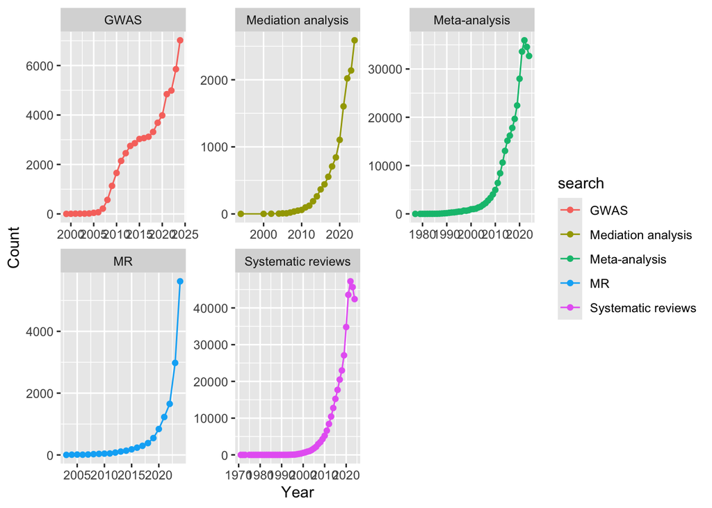

```r
ggplot(dat, aes(x=Year, y=Count, color=search)) + geom_line() + geom_point() + facet_wrap(~search, scale="free")
```

The x and y axes have very different scales. Normalise by dividing by the maximum count for each search term.

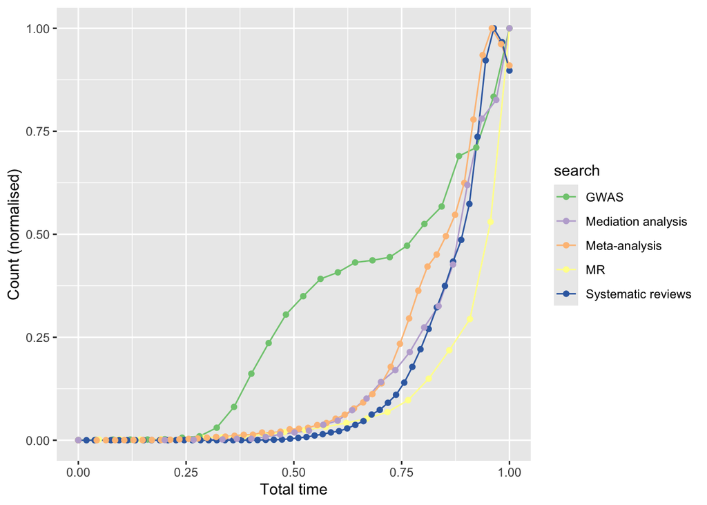

```r
dat %>%
ggplot(., aes(x=time, y=countn, color=search)) + geom_line() + geom_point() + scale_colour_brewer(type="qual") + labs(x="Total time", y="Count (normalised)")
```

MR is clearly growing quite rapidly on this scale. Try just plotting from 2000 onwards:

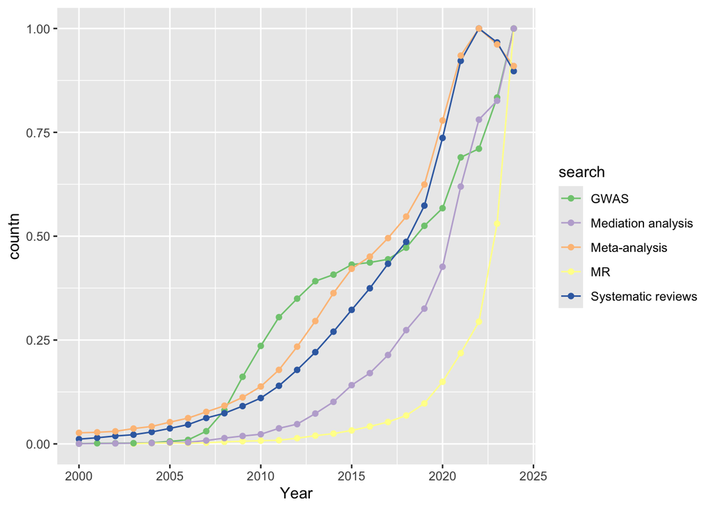

```r
dat %>%
    filter(Year >= 2000 & Year <= 2024) %>%
ggplot(., aes(x=Year, y=countn, color=search)) + geom_line() + geom_point() + scale_colour_brewer(type="qual")
```

Normalise by the number of publications in PubMed in general.

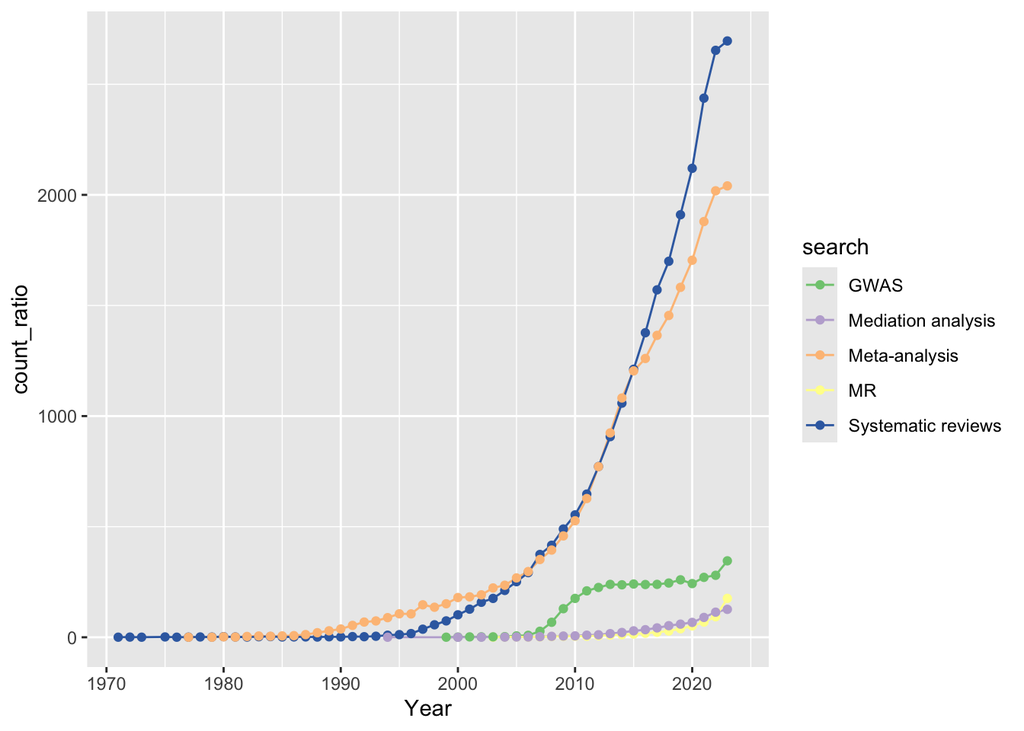

```r
# From https://esperr.github.io/pubmed-by-year/
pby <- read.csv(here("data/pubmed_counts/PubMed by Year.csv"), header=TRUE) %>% as_tibble()
names(pby)[-1] <- unique(dat$search)
pby <- pby %>% gather(key="search", value="count_ratio", -Year)

dat <- left_join(dat, pby, by=c("Year", "search"))
dat <- group_by(dat, search) %>% mutate(count_ratio_norm = count_ratio/max(count_ratio, na.rm=T)) %>% ungroup()

dat %>% ggplot(., aes(x=Year, y=count_ratio, color=search)) + geom_line() + geom_point() + scale_colour_brewer(type="qual")
```

Normalising by number of pubmed publications doesn’t actually change the shape that much for these topics. Try normalising by the maximum number of publications for each search term.

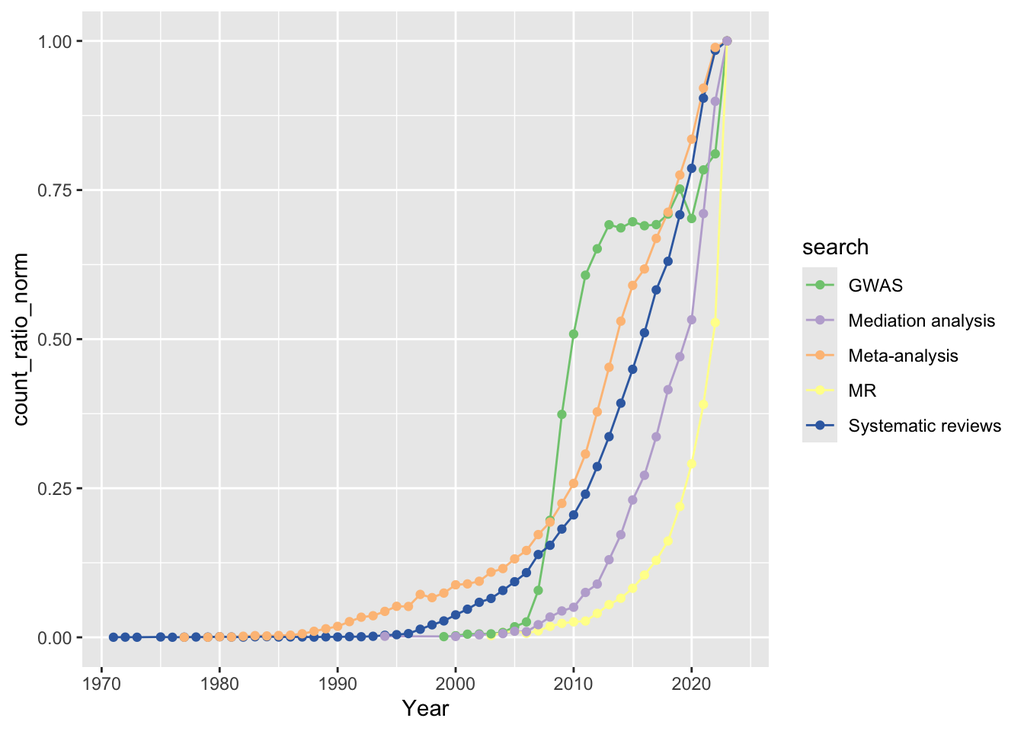

```r
dat <- group_by(dat, search) %>% mutate(count_ratio_norm = count_ratio / max(count_ratio, na.rm=T)) %>% ungroup()
dat %>% ggplot(., aes(x=Year, y=count_ratio_norm, color=search)) + geom_line() + geom_point() + scale_colour_brewer(type="qual")
```

Similar story to before standardising by the number of pubmed publications.

Estimate exponential growth

```r
calculate_exp_growth <- function(time, counts) {
    # Fit exponential model by taking log of counts
    # N(t) = N0 * e^(rt) becomes log(N(t)) = log(N0) + rt
    model <- lm(log(counts) ~ time)

    # Extract growth coefficient (r)
    r <- coef(model)[2]

    # Calculate R-squared to assess fit
    r_squared <- summary(model)$r.squared

    # Calculate doubling time
    doubling_time <- log(2)/r

    # Return results
    return(list(
        growth_coefficient = r,
        r_squared = r_squared,
        doubling_time = doubling_time,
        initial_value = exp(coef(model)[1])
    ) %>% as_tibble())
}

l <- list()
l[[1]] <- dat %>% filter(Year >= 2000 & Year <= 2024) %>%
    group_by(search) %>% do({
        calculate_exp_growth(.$Year, .$countn)
    }) %>% select(search, doubling_time_2003 = doubling_time)

l[[2]] <- dat %>% filter(Year <= 2024) %>%
    group_by(search) %>% do({
        x <- .
        x <- subset(x, Count != 0)
        calculate_exp_growth(x$Year, x$count_ratio)
    }) %>% select(search, doubling_time_all = doubling_time)

l[[3]] <- group_by(dat, search) %>% summarise(total = sum(Count), count_2024 = max(Count), ratio = count_2024 / total)

Reduce(function(x, y) merge(x, y, by="search"), l) %>% arrange(desc(ratio)) %>% knitr::kable()
```

| search | doubling_time_2003 | doubling_time_all | total | count_2024 | ratio |
| --- | --- | --- | --- | --- | --- |
| MR | 2.208058 | 2.750566 | 14495 | 5619 | 0.3876509 |
| Mediation analysis | 2.132870 | 2.667047 | 13235 | 2589 | 0.1956177 |
| Systematic reviews | 3.557730 | 3.583120 | 380924 | 47245 | 0.1240274 |
| GWAS | 2.282179 | 2.505735 | 56857 | 7021 | 0.1234852 |
| Meta-analysis | 4.067593 | 4.114678 | 324290 | 35938 | 0.1108206 |

To summarise, MR does have a relatively fast doubling time compared to other similar topics. However it is not an extreme outlier in terms of its rapid growth.